# Lecture 10

March 14, 2016

## Conclusion of a Hypothesis Test

Why the hair-splitting between

- Failing to reject \(H_0\)
- Accepting \(H_0\)

## Conclusion of a Hypothesis Test

Because

- **absense of evidence is not evidence of absense**
- Example of the **black swan fallacy**: just because you've never seen a black swan, doesn't mean black swans don't exist.

## Example: Male vs Female Run Times

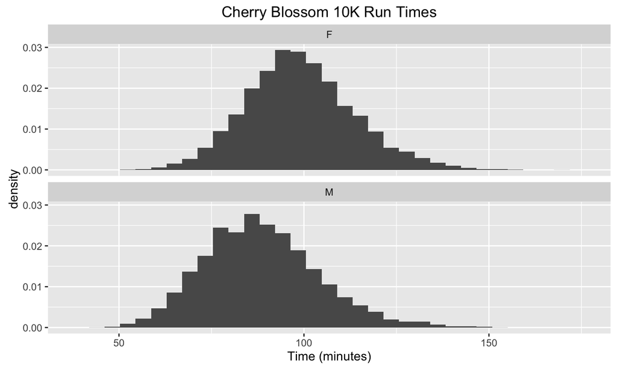

## Population

We **know** \(\mu_F - \mu_M \neq 0\)

| gender | mean | n |
| --- | --- | --- |
| F | \(\mu_F = 99.0\) | 9732 |
| M | \(\mu_M = 88.4\) | 7192 |

## Hypothesis Test

We still conduct a hypothesis test at \(\alpha=0.05\)

\[ \begin{eqnarray*} && H_0: \mu_F - \mu_M = 0\\ \text{vs}&& H_A: \mu_F - \mu_M \neq 0\\ \end{eqnarray*} \]

with a sample of 2 women and 3 men…

## The Sample

| gender | time |
| --- | --- |
| F | 54.40 |
| F | 54.03 |
| M | 148.97 |
| M | 150.98 |
| M | 147.50 |

\(\text{}\)

i.e. the observed difference \(\overline{x}_F - \overline{x}_M\) = -94.9.

## Null Distribution

An exhaustive two-sample permutation test yields a \(p\)-value of 0.2:

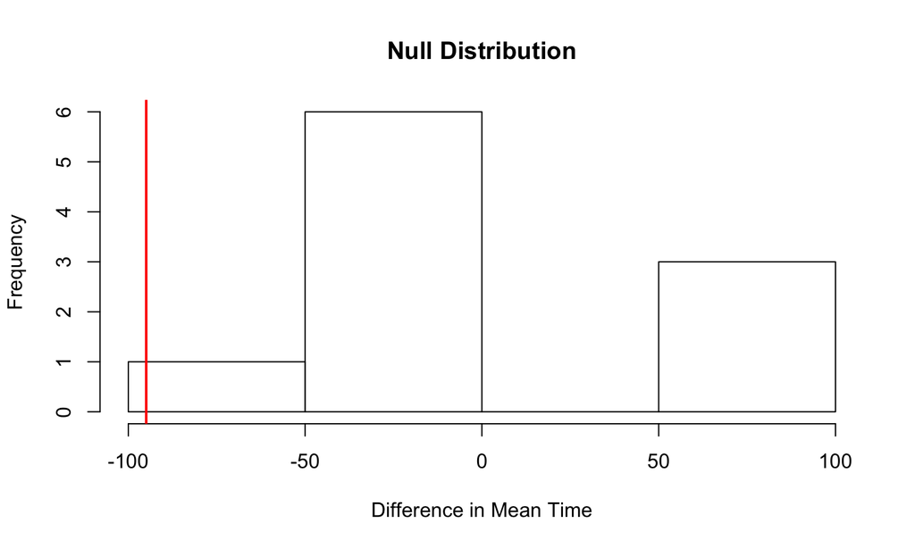

## Conclusion

\(p\)-value = \(0.2 > \alpha =0.05\)

Conclusions:

- **We accept \(H_0\)**: men have the same mean running time as women. **NOT TRUE**
- **We fail to reject \(H_0\)**: nothing suggests they are not the same.

The latter is more conservative and correct.

## What I Facebook about

[figure not shown]

## Confidence Intervals

We want to infer about an unknown parameter \(\theta\). Using just a point estimate \(\widehat{\theta}\) is akin to:

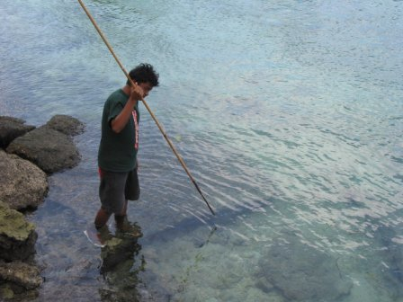

## Confidence Intervals

Whereas using a **confidence interval** is akin to:

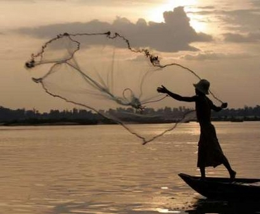

## Interpretation

Say \(\mu=94.52\) is the true population mean. Let each confidence interval be based on a different random sample \(\vec{x}\) of size \(n\).

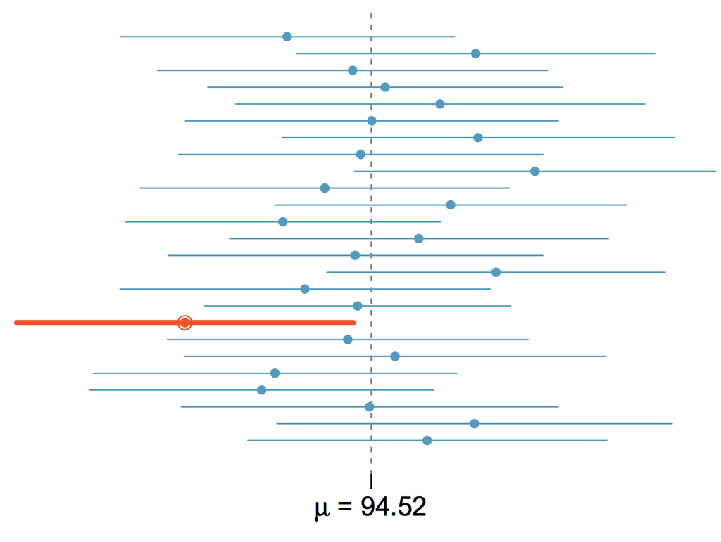